# Predicting Attendance for Tampa Bay Rays Games

## Introduction

For the purposes of this paper, I will be evaluating the extent to which opponents, day of week, and other variables impacted ticket sales across MLB in the 2024 season, as well as how promotions impacted ticket sales for the Tampa Bay Rays for the 2022-2024 seasons. All analysis and visualization was done in Python.

## Literature Review

In the late 2010s, baseball saw significant declines in attendance. Ronald Blumap (2018) reported that in 2018, MLB’s average attendance dropped 4% from the prior year, and marked the lowest since 2003. Six stadiums set record lows, and 17 of 30 teams experienced the decline in attendance (Blumap 2018). Baseball experienced a similar decline in 2019, with Danielle Allentuck and Kevin Draper (2019) reporting that total attendance dropped again by about 1 million fans. This trend continued into the early 2020s, with Jason Foster (2022) reporting that attendance dropped again in 2021, hitting a 37-year low. Amidst the attendance challenges, some teams have resorted to creative new ticketing strategies, such as ticket subscriptions. By 2019, 18 of 30 teams had introduced some sort of ticket subscription options (Allentuck and Draper 2019).

Not only has attendance been down, but general popularity as well. A poll published by Seton Hall revealed that of 1,570 respondents, 44% of “avid” sports fans said they would be less interested in the sport when the 2022 season began in the midst of the 2022 lockout (Foster 2022). 54% of the general public reported that they had no interest in baseball anyway (Foster 2022).

Given the data above, the challenges that MLB faces are clear: what can they do to stop the attendance decline and increase popularity of the sport?

## Relationship Between Relevant Factors and Ticket Sales

```python
import pandas as pd
import matplotlib.pyplot as plt
import numpy as np
import datetime
import math
from time import strptime
from IPython.display import display
import seaborn as sns
from sklearn.model_selection import train_test_split
import sklearn.metrics as metrics
from sklearn.linear_model import LinearRegression
from sklearn.metrics import classification_report, confusion_matrix
from sklearn.feature_selection import f_regression
import scipy
import statsmodels.api as sm
sns.set()
pd.set_option('display.max_rows', None)
pd.set_option('display.max_columns', None)
pd.set_option('display.width', None)
pd.set_option('display.max_colwidth', None)
```

```python
df = pd.read_csv('mlb 2024.csv')
df = df[df['Unnamed: 4'] != '@']
df = df.reset_index(drop=True)
df = df.drop(df.columns[[0,2,4,6,7,8,9,10,13,14,15,16,20,21]], axis=1)

#Converting the Date column to day of week and actual date
df['Day of Week'] = df['Date'].apply(lambda x: str(x).split(',')[0])
df['Month'] = df['Date'].apply(lambda x: str(x).split(' ')[1])
df = df.drop(df.columns[[0]], axis=1)

#Converting GB to float
df['GB'] = df['GB'].str.replace('up ', '-', regex=False)
df['GB'] = df['GB'].str.replace('up', '-', regex=False)
df['GB'] = df['GB'].apply(lambda x: float(x) if '-' in str(x) else (float(0) if 'Tied' in str(x) else float(x)))

#Converting D/N to 'Day' and 'Night'
df['D/N'] = df['D/N'].replace('D','Day')
df['D/N'] = df['D/N'].replace('N','Night')

df.head(5)
```

|  | Tm | Opp | Rank | GB | D/N | Attendance | cLI | Day of Week | Month |
| --- | --- | --- | --- | --- | --- | --- | --- | --- | --- |
| 0 | WSN | PIT | 2 | 2.0 | Day | 40405.0 | 0.96 | Monday | Apr |
| 1 | WSN | PIT | 2 | 1.0 | Night | 14022.0 | 0.89 | Wednesday | Apr |
| 2 | WSN | PIT | 2 | 1.5 | Day | 11135.0 | 0.95 | Thursday | Apr |
| 3 | WSN | PHI | 3 | 2.5 | Night | 21374.0 | 0.94 | Friday | Apr |
| 4 | WSN | PHI | 3 | 3.5 | Day | 29718.0 | 0.88 | Saturday | Apr |

```python
df_for_graphs = df
```

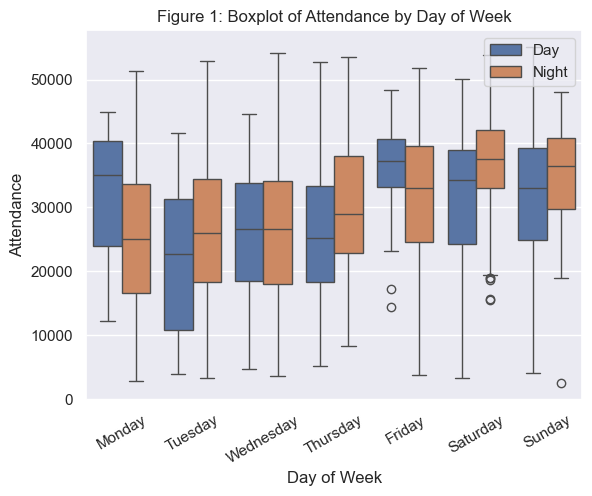

```python
# Creating the Boxplot for Day of Week
sns.boxplot(y='Attendance', x='Day of Week', data = df_for_graphs, order = ['Monday', 'Tuesday', 'Wednesday', 'Thursday', 'Friday', 'Saturday', 'Sunday'],
           hue = 'D/N')

# Customizing the plot
plt.title('Figure 1: Boxplot of Attendance by Day of Week')
plt.xlabel('Day of Week')
plt.ylabel('Attendance')
plt.tick_params(axis='x', labelrotation=30)
plt.legend(loc='upper right')
plt.show()
```

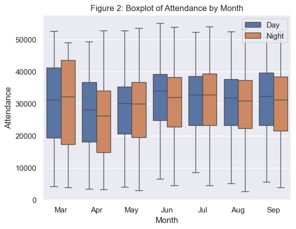

```python
# Creating the Boxplot for Month
sns.boxplot(y='Attendance', x='Month', data = df_for_graphs, order = ['Mar', 'Apr', 'May', 'Jun', 'Jul', 'Aug', 'Sep'], hue = 'D/N')

# Customizing the plot
plt.title('Figure 2: Boxplot of Attendance by Month')
plt.xlabel('Month')
plt.ylabel('Attendance')
#plt.tick_params(axis='x')
plt.legend(loc='upper right')
plt.show()
```

Looking at Figure 1, it can be concluded that day of week definitely influenced attendance, with weekend games showing higher attendance than weekday games. It can also be concluded that the time of the game on these days also had an effect, with night games showing mostly greater attendance and tighter distributions. It is interesting to see that Monday day games had much larger attendance than night games, but this is most likely due to Monday day games not being very common and often occurring on Opening Day, when attendance is usually the highest it is all season. Figure 2 shows that month also affected attendance, with April and May showing lower attendance than later months. The higher numbers for March can also most likely be attributed to Opening Day and the start of the season.

The next step was to see how opponent affected attendance. Common sense would be that popular teams like the New York Yankees and Los Angeles Dodgers being the visiting team would boost attendance. A boxplot showing attendance by opponent can be seen in in Figure 3. Looking at the figure, it does show that attendance ranges and medians can absolutely be affected by opponents. The Yankees and Dodgers have the two highest medians, while also having the smallest ranges, indicating that playing these opponents increased the attendance floor.

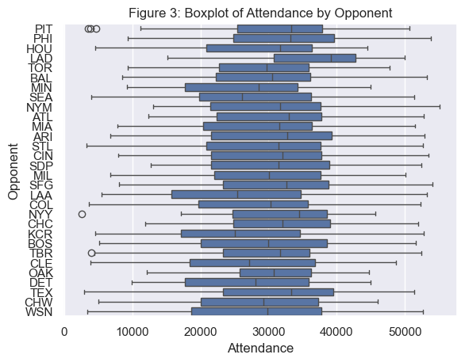

```python
# Creating the Boxplot for Team
sns.boxplot(data=df_for_graphs, x="Attendance", y="Opp")

# Customizing the plot
plt.title('Figure 3: Boxplot of Attendance by Opponent')
plt.xlabel('Attendance')
plt.ylabel('Opponent')
#plt.tick_params(axis='x')
plt.show()
```

To see how team performance affected attendance, number of games back in the division and cLI (championship leverage index) were used. cLI is a statistic created by Baseball Reference that indicates the importance of the game on the team’s World Series probabilities where 1 indicates average, below 1 indicates below average, and above 1 indicates above average. An initial plot of cLI showed that the distribution extremely skewed to the right, so the log of the value was used instead. Values of 0 were converted to 0.001 prior to the log conversion to avoid error. Scatter plots for these distributions can be seen below in Figure 4 and Figure 5. These plots show that team performance did affect attendance, with cLI showing a positive relationship with attendance (meaning that games more important to World Series chances showed higher attendance), and GB showing a negative relationship with attendance (meaning that the further back a team was in the division coincided with lower attendance).

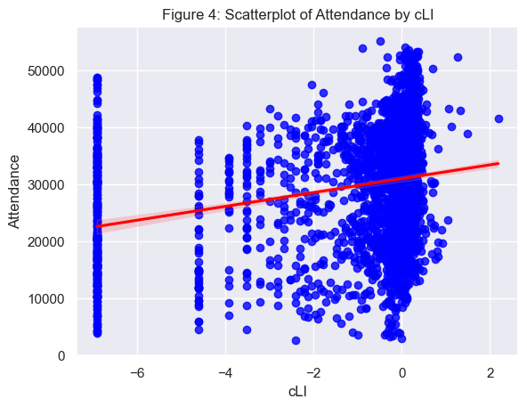

```python
# Creating the Scatterplot for cLI
df_for_graphs['cLI'] = df_for_graphs['cLI'].replace(0,0.001)
df_for_graphs['Log cLI'] = np.log(df_for_graphs['cLI'])
#sns.scatterplot(data=df_for_graphs, x="Log cLI", y="Attendance", color = 'blue')
sns.regplot(data=df_for_graphs, x="Log cLI", y="Attendance", scatter_kws={"color": "blue"}, line_kws={"color": "red"})

# Customizing the plot
plt.title('Figure 4: Scatterplot of Attendance by cLI')
plt.xlabel('cLI')
plt.ylabel('Attendance')
#plt.tick_params(axis='x')
plt.show()
```

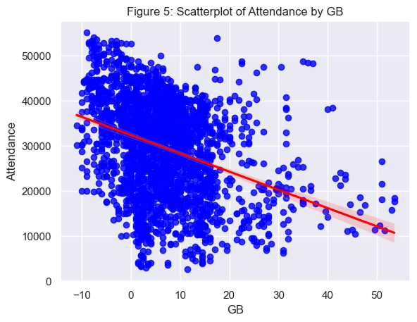

```python
# Creating the Scatterplot for GB
#df_for_graphs['Log cLI'] = np.log(df['cLI'])
sns.regplot(data=df_for_graphs, x="GB", y="Attendance", scatter_kws={"color": "blue"}, line_kws={"color": "red"})

# Customizing the plot
plt.title('Figure 5: Scatterplot of Attendance by GB')
plt.xlabel('GB')
plt.ylabel('Attendance')
#plt.tick_params(axis='x')
plt.show()
```

After seeing how these factors affected attendance across MLB, I wanted to see how promotions (as well as the other factors) affected attendance for the Tampa Bay Rays from 2022-2024. Similar to above, attendance data from Rays home games in 2022 (“2022 Tampa Bay Rays Schedule,” n.d.), 2023 (“2023 Tampa Bay Rays Schedule,” n.d.), and 2024 (“2024 Tampa Bay Rays Schedule,” n.d.) was gathered from Baseball Reference in the form of csv files and then loaded into Python for analysis. This data also required cleaning and filtering. First, a number of unneeded columns were removed. Next, the ‘Date’ column was cleaned so that they could be merged with the promotions later on, as well as converted to separate ‘Month’ and ‘Day of Week’ columns. The three datasets were then merged to create one large dataset. The ‘GB’ column was updated to make the ‘Tie’ value equal to 0 and the ‘up’ values changed to negative however many games the team was up in the division. Finally, ‘D’ and ‘N’ values in the ‘D/N’ column were replaced with ‘Day’ and ‘Night’. These steps can be seen below, along with an example of what the data looked like.

```python
df_rays_2024 = pd.read_csv('rays_2024.csv')
df_rays_2024 = df_rays_2024[df_rays_2024['Unnamed: 4'] != '@']
df_rays_2024['GB'] = df_rays_2024['GB'].astype(str)

df_rays_2023 = pd.read_csv('rays_2023.csv')
df_rays_2023 = df_rays_2023[df_rays_2023['Unnamed: 4'] != '@']
df_rays_2023['GB'] = df_rays_2023['GB'].astype(str)

df_rays_2022 = pd.read_csv('rays_2022.csv')
df_rays_2022 = df_rays_2022[df_rays_2022['Unnamed: 4'] != '@']
df_rays_2022['GB'] = df_rays_2022['GB'].astype(str)

#Converting the Date column to day of week and actual date
df_rays_2024['Day of Week'] = df_rays_2024['Date'].apply(lambda x: str(x).split(' ')[0])
df_rays_2024['Month'] = df_rays_2024['Date'].apply(lambda x: str(x).split(' ')[1])
df_rays_2024['month'] = [strptime(str(x), '%b').tm_mon for x in df_rays_2024['Month']]
df_rays_2024['year'] = '2024'
df_rays_2024['day'] = df_rays_2024['Date'].apply(lambda x: int(str(x).split(' ')[2]))
df_rays_2024['dateInt']=df_rays_2024['year'].astype(str) + df_rays_2024['month'].astype(str).str.zfill(2)+ df_rays_2024['day'].astype(str).str.zfill(2)
df_rays_2024['Date'] = pd.to_datetime(df_rays_2024['dateInt'], format='%Y%m%d')

#Converting the Date column to day of week and actual date
df_rays_2023['Day of Week'] = df_rays_2023['Date'].apply(lambda x: str(x).split(' ')[0])
df_rays_2023['Month'] = df_rays_2023['Date'].apply(lambda x: str(x).split(' ')[1])
df_rays_2023['month'] = [strptime(str(x), '%b').tm_mon for x in df_rays_2023['Month']]
df_rays_2023['year'] = '2023'
df_rays_2023['day'] = df_rays_2023['Date'].apply(lambda x: int(str(x).split(' ')[2]))
df_rays_2023['dateInt']=df_rays_2023['year'].astype(str) + df_rays_2023['month'].astype(str).str.zfill(2)+ df_rays_2023['day'].astype(str).str.zfill(2)
df_rays_2023['Date'] = pd.to_datetime(df_rays_2023['dateInt'], format='%Y%m%d')

#Converting the Date column to day of week and actual date
df_rays_2022['Day of Week'] = df_rays_2022['Date'].apply(lambda x: str(x).split(' ')[0])
df_rays_2022['Month'] = df_rays_2022['Date'].apply(lambda x: str(x).split(' ')[1])
df_rays_2022['month'] = [strptime(str(x), '%b').tm_mon for x in df_rays_2022['Month']]
df_rays_2022['year'] = '2022'
df_rays_2022['day'] = df_rays_2022['Date'].apply(lambda x: int(str(x).split(' ')[2]))
df_rays_2022['dateInt']=df_rays_2022['year'].astype(str) + df_rays_2022['month'].astype(str).str.zfill(2)+ df_rays_2022['day'].astype(str).str.zfill(2)
df_rays_2022['Date'] = pd.to_datetime(df_rays_2022['dateInt'], format='%Y%m%d')

#Merging the attendance data
df_rays_merged = pd.concat([df_rays_2024, df_rays_2023, df_rays_2022], ignore_index = True, sort = False)
df_rays_merged = df_rays_merged.drop(df_rays_merged.columns[[0,2,3,4,6,7,8,9,10,13,14,15,16,20,21,24,25,26,27]], axis=1)

#Converting GB to float
df_rays_merged['GB'] = df_rays_merged['GB'].astype(str)
df_rays_merged['GB'] = df_rays_merged['GB'].str.replace('up ', '-',)
df_rays_merged['GB'] = df_rays_merged['GB'].str.replace('up', '-', regex=False)
df_rays_merged['GB'] = df_rays_merged['GB'].apply(lambda x: float(x) if '-' in str(x) else (float(0) if 'Tied' in str(x) else float(x)))

#Converting D/N to 'Day' and 'Night'
df_rays_merged['D/N'] = df_rays_merged['D/N'].replace('D','Day')
df_rays_merged['D/N'] = df_rays_merged['D/N'].replace('N','Night')

df_rays_merged.head(5)
```

|  | Date | Opp | Rank | GB | D/N | Attendance | cLI | Day of Week | Month |
| --- | --- | --- | --- | --- | --- | --- | --- | --- | --- |
| 0 | 2024-03-28 | TOR | 5 | 1.0 | Day | 25025 | 0.99 | Thursday | Mar |
| 1 | 2024-03-29 | TOR | 3 | 1.0 | Night | 18653 | 0.96 | Friday | Mar |
| 2 | 2024-03-30 | TOR | 3 | 1.0 | Day | 18905 | 0.95 | Saturday | Mar |
| 3 | 2024-03-31 | TOR | 3 | 2.0 | Day | 14875 | 1.02 | Sunday | Mar |
| 4 | 2024-04-01 | TEX | 4 | 3.0 | Night | 14144 | 0.91 | Monday | Apr |

Promotion data from 2022 was gathered from an article published by Dan Trujillo (2022), while 2023 and 2024 promotion data was gathered from articles by Daniel Russell (2023) and (2024), respectively. Promotions were split into four categories based on what the giveaways were: apparel (hats, jerseys, shirts, etc.) bobbleheads, kids (giveaways to all kids in attendance), and miscellaneous (magnets, bats, etc.). The data was put into a csv file and then loaded into Python for analysis. This dataframe and the attendance dataframe were merged, adding a ‘promotion’ column to signify whether or not there was a promotion and what type. These steps can be seen below, along with an example of what the data looked like.

```python
#Importing promotions and joining with attendance data
promotions = pd.read_csv('Rays giveaways.csv')
promotions['Date'] = pd.to_datetime(promotions['date'])
promotions = promotions.drop('date', axis = 1)
attendance_merged = pd.merge(df_rays_merged, promotions, on = 'Date', how = 'left')
attendance_merged = attendance_merged.drop('Date', axis = 1)
attendance_merged = attendance_merged.drop('Rank', axis = 1)
attendance_merged.head(5)
```

|  | Opp | GB | D/N | Attendance | cLI | Day of Week | Month | giveaway |
| --- | --- | --- | --- | --- | --- | --- | --- | --- |
| 0 | TOR | 1.0 | Day | 25025 | 0.99 | Thursday | Mar | Misc |
| 1 | TOR | 1.0 | Night | 18653 | 0.96 | Friday | Mar | NaN |
| 2 | TOR | 1.0 | Day | 18905 | 0.95 | Saturday | Mar | NaN |
| 3 | TOR | 2.0 | Day | 14875 | 1.02 | Sunday | Mar | Misc |
| 4 | TEX | 3.0 | Night | 14144 | 0.91 | Monday | Apr | NaN |

Similarly to the analysis across the league, once the attendance data was cleaned and filtered, the first step was to create exploratory graphics to look at specific variables and how they affected attendance. Figure 6 and Figure 7 below show boxplots of attendance versus day of week and month, respectively, stratified by start time. The first plot shows that day of week has a significant effect on attendance, with weekend games having higher attendance. The second plot shows that month also has an effect, and that there is a significant difference in attendance for day and night games in the early months of the season.

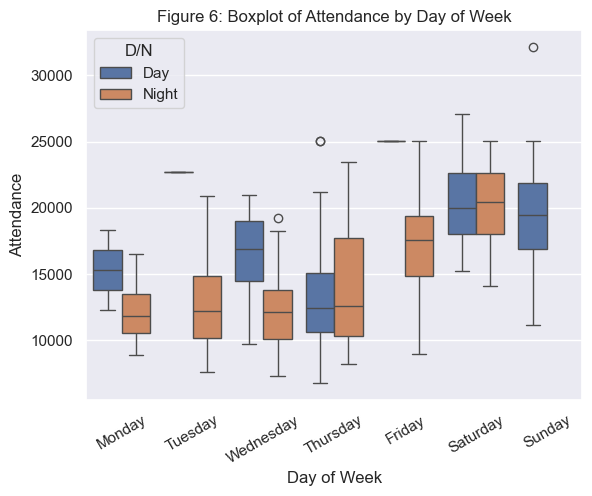

```python
# Creating the Boxplot for Day of Week
sns.boxplot(y='Attendance', x='Day of Week', data = attendance_merged, order = ['Monday', 'Tuesday', 'Wednesday', 'Thursday', 'Friday', 'Saturday', 'Sunday'],
            hue = "D/N")

# Customizing the plot
plt.title('Figure 6: Boxplot of Attendance by Day of Week')
plt.xlabel('Day of Week')
plt.ylabel('Attendance')
plt.tick_params(axis='x', labelrotation=30)
plt.show()
```

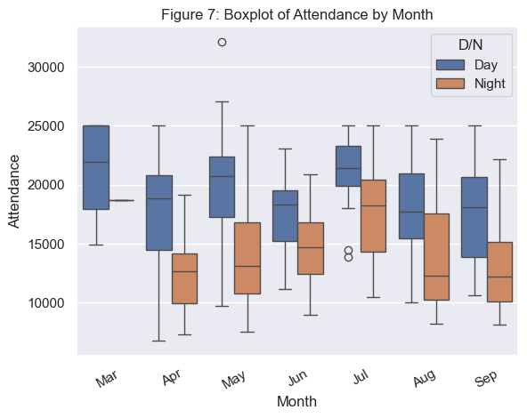

```python
# Creating the Boxplot for Month
sns.boxplot(y='Attendance', x='Month', data = attendance_merged, hue = "D/N")

# Customizing the plot
plt.title('Figure 7: Boxplot of Attendance by Month')
plt.xlabel('Month')
plt.ylabel('Attendance')
plt.tick_params(axis='x', labelrotation=30)
plt.show()
```

However, logically, I was worried that there could be a correlation between day of week and start time, and multicollinearity could negatively affect the regression model. Oftentimes, Wednesday, Thursday, and Sunday games are games known as “getaway” games, where the game is started early so that one or both of the teams can travel after the game for their next series. To look at the correlation between the variables, I calculated Cramer’s V coefficient between the variables. Cramer’s V coefficient is a measure of association between categorical variables, based on Pearson’s chi-squared statistic.

```python
df_for_vif = attendance_merged.drop(['Attendance'],axis = 1)
CrosstabResult = pd.crosstab(index=df_for_vif['D/N'], columns=df_for_vif['Day of Week'])
association = scipy.stats.contingency.association(CrosstabResult)
print("The Cramer's V coefficient between day of week and start time is", round(association,4))
```

```
The Cramer's V coefficient between day of week and start time is 0.7799
```

The coefficient between the variables was 0.78, meaning that the two variables were highly correlated. Thus, I decided to remove one of the variables. Later model output showed that the model performed better with day of week included in the model as opposed to start time, so start time was removed.

Similarly, another factor I wanted to consider was opponent. Figure 8 shows boxplots for attendance for each opponent. The plots show that opponents absolutely can affect attendance for the Rays. One potential flaw in this graphic is that National League teams only visit every other year, and have less data points than all American League Teams and far less than American League East Teams, who visit for 6 or 7 games a year.

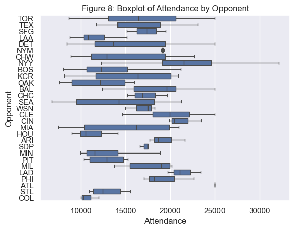

```python
# Creating the Boxplot for Team
sns.boxplot(data=attendance_merged, x="Attendance", y="Opp")

# Customizing the plot
plt.title('Figure 8: Boxplot of Attendance by Opponent')
plt.xlabel('Attendance')
plt.ylabel('Opponent')
#plt.tick_params(axis='x')
plt.show()
```

I also wanted to examine how team performance affected attendance. When trying to address team performance, I initially included both cLI and number of games back in the division. Both of these variables showed a relationship with attendance, as can be seen below in Figure 9 and Figure 10.

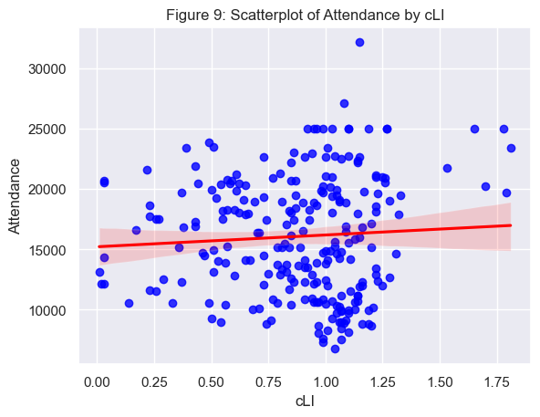

```python
# Creating the Scatterplot for cLI
sns.regplot(data=attendance_merged, x="cLI", y="Attendance", scatter_kws={"color": "blue"}, line_kws={"color": "red"})

# Customizing the plot
plt.title('Figure 9: Scatterplot of Attendance by cLI')
plt.xlabel('cLI')
plt.ylabel('Attendance')
#plt.tick_params(axis='x')
plt.show()
```

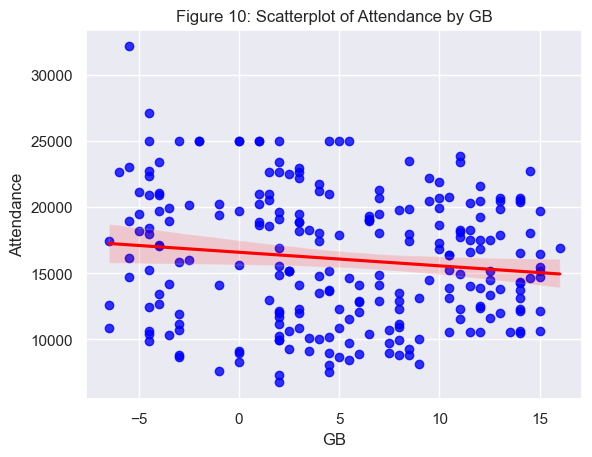

```python
# Creating the Scatterplot for GB
sns.regplot(data=attendance_merged, x="GB", y="Attendance", scatter_kws={"color": "blue"}, line_kws={"color": "red"})

# Customizing the plot
plt.title('Figure 10: Scatterplot of Attendance by GB')
plt.xlabel('GB')
plt.ylabel('Attendance')
#plt.tick_params(axis='x')
plt.show()
```

Once again, logically, these two measures would seem to be highly correlated. The further you are back in the division, most likely the lower the cLI is and vice versa. I wanted to test and see if there was multicollinearity between the variables so I calculated the variance inflation factor (VIF) for the variables.

```python
#Checking to see correlation between GB and CLI
from statsmodels.stats.outliers_influence import variance_inflation_factor

X = attendance_merged[['GB', 'cLI']]

vif_data = pd.DataFrame()
vif_data["feature"] = X.columns

vif_data["VIF"] = [variance_inflation_factor(X.values, i)
                          for i in range(len(X.columns))]
print(vif_data)
```

```
  feature       VIF
0      GB  1.249718
1     cLI  1.249718
```

```python
#Removing GB and D/N because the variables are highly correlated
attendance_merged = attendance_merged.drop(['GB', 'D/N'], axis = 1)
```

```python
"""
MODEL ACCURACY METRICS
"""
def print_Accuracy(TITLE, LIST) :
    print( TITLE )
    print( "======" )
    for theResults in LIST :
        NAME = theResults[0]
        ACC = theResults[1]
        print( NAME, " = ", ACC )
    print( "------\n\n" )

def getAttAccuracyScores(NAME, MODEL, X, Y) :
    pred = MODEL.predict(X)
    MEAN = Y.mean()
    RMSE = math.sqrt( metrics.mean_squared_error(Y, pred))
    return [NAME, RMSE, MEAN]

def getCoefLinear(MODEL, TRAIN_DATA) :
    varNames = list(TRAIN_DATA.columns.values)
    coef_dict = {}
    coef_dict["INTERCEPT"] = MODEL.intercept_
    for coef, feat in zip(MODEL.coef_,varNames):
        coef_dict[feat] = coef
    #coef_dict = sorted(coef_dict, key=lambda dict_key: abs(coef_dict[dict_key]))
    #sorted_dict = dict(sorted(coef_dict.items(), key=lambda item: abs(item[1]), reverse = True))
    mod = sm.OLS(Y,X.astype(float))
    fii = mod.fit()
    p_values = fii.summary2().tables[1]['P>|t|']
    print("\nATTENDANCE")
    print("---------")
    print("Total Variables: ", len(coef_dict)-1)
    for i in coef_dict :
        if i == 'INTERCEPT':
          sig = ''
        else:
          p_value = p_values.loc[i]
          if p_value <= 0.01:
            sig = '***'
          elif p_value <= 0.05:
            sig = '**'
          elif p_value <= 0.1:
            sig = '*'
          else:
            sig = ''
        print(i, " = ", round(coef_dict[i],3),sig)
    # for i in sorted_dict :
    #     print(i, " = ", round(sorted_dict[i],3))
    print('\nNote: \n*** implies significant at the alpha = .01 level\n ** implies significant at the alpha = .05 level\n  * implies significant at the alpha = .10 level')
```

```python
df = attendance_merged

TARGET_A = "Attendance"

#One-hot encoding to convert categorical column values to boolean
for i in ['giveaway']:
  thePrefix = "Promotion:"
  y = pd.get_dummies(df[i], prefix = thePrefix, dummy_na=False, prefix_sep=' ')
  df = pd.concat([df, y], axis=1)
  df = df.drop(i, axis=1)

for i in ['Day of Week']:
  thePrefix = "Day of Week:"
  y = pd.get_dummies(df[i], prefix = thePrefix, dummy_na=False, prefix_sep=' ')
  df = pd.concat([df, y], axis=1)
  df = df.drop(i, axis=1)
for i in ['Month']:
  thePrefix = "Month:"
  y = pd.get_dummies(df[i], prefix = thePrefix, dummy_na=False, prefix_sep=' ')
  df = pd.concat([df, y], axis=1)
  df = df.drop(i, axis=1)

for i in ['Opp']:
  thePrefix = "Opp:"
  y = pd.get_dummies(df[i], prefix = thePrefix, dummy_na=False, prefix_sep=' ')
  df = pd.concat([df, y], axis=1)
  df = df.drop(i, axis=1)
```

```python
#ATTENDANCE

X = df.copy()
X = X.drop(TARGET_A, axis=1)

Y = df[[TARGET_A]]

ATT = LinearRegression()
ATT = ATT.fit(X, Y[TARGET_A])


ATT_accuracy = getAttAccuracyScores("REGRESSION", ATT, X, Y[TARGET_A])

REG_ALL_ATT_COEF = getCoefLinear(ATT, X)
print("\n")
print("Observations: " + str(len(X)))
print("R Squared: " + str(round(ATT.score(X, Y[TARGET_A]),3)))
print("RMSE: ",round(ATT_accuracy[1],3))
Rsq = ATT.score(X, Y[TARGET_A])
fstat = (Rsq/(1-Rsq))*((len(X)-len(X.columns)-1)/len(X.columns))
print("F Statistic: ",round(fstat,3))

dfN = len(X.columns) - 1 #degrees of freedom in the numerator of F-statistic
dfD = len(X) - dfN #degrees of freedom in the denominator of F-statistic

pVal = 1 - scipy.stats.f.cdf(fstat, dfN, dfD)
print("P Value: ",pVal)
```

```
ATTENDANCE
---------
Total Variables:  48
INTERCEPT  =  16205.11
cLI  =  -223.553
Promotion: Apparel  =  1947.084
Promotion: Bobblehead  =  1370.666
Promotion: Kids  =  2072.917 *
Promotion: Misc  =  2909.24 ***
Day of Week: Friday  =  737.552 ***
Day of Week: Monday  =  -1821.45 ***
Day of Week: Saturday  =  3721.572 ***
Day of Week: Sunday  =  1900.415 ***
Day of Week: Thursday  =  -1193.42 ***
Day of Week: Tuesday  =  -1748.75 ***
Day of Week: Wednesday  =  -1595.919 ***
Month: Apr  =  -298.282 ***
Month: Aug  =  -873.967 ***
Month: Jul  =  62.929 ***
Month: Jun  =  -91.649 ***
Month: Mar  =  2788.361 ***
Month: May  =  -998.093 ***
Month: Sep  =  -589.298 ***
Opp: ARI  =  1269.655
Opp: ATL  =  5897.627 ***
Opp: BAL  =  770.811 ***
Opp: BOS  =  -1176.648
Opp: CHC  =  2751.676 **
Opp: CHW  =  -1773.533
Opp: CIN  =  2544.22 **
Opp: CLE  =  909.896 **
Opp: COL  =  -2835.047
Opp: DET  =  -755.637
Opp: HOU  =  -2781.14
Opp: KCR  =  -1940.638
Opp: LAA  =  -2153.99
Opp: LAD  =  2957.022 **
Opp: MIA  =  1053.013 *
Opp: MIL  =  1290.976 **
Opp: MIN  =  -2782.067
```

[output cut: 9 more lines]

```
Opp: TEX  =  -405.337
Opp: TOR  =  -835.109
Opp: WSN  =  -1662.399

Note:
*** implies significant at the alpha = .01 level
 ** implies significant at the alpha = .05 level
  * implies significant at the alpha = .10 level


Observations: 243
R Squared: 0.637
RMSE:  2959.731
F Statistic:  7.107
P Value:  1.1102230246251565e-16
```

Knowing that these variables had a statistically significant relationship with attendance, the next step to see was if they could reasonably predict attendance. The data was split into a training set (80%) and a test set (20%). The model was trained on the training set and tested on the test set. Testing the model on the test set resulted in an RMSE of 3272, and running it over the training set resulted in an RMSE of 2955. This indicates that the model performed slightly better on the training set than the test set, but there was not a significant difference in performance. The model output can be seen below, as well as scatterplots showing the performance of the model.

```python
#Creating a model to predict attendance based on promotion and other data
"""
SPLIT DATA
"""

X = df.copy()
X = X.drop(TARGET_A, axis=1)

Y = df[[TARGET_A]]

X_train, X_test, Y_train, Y_test = train_test_split(X, Y, train_size=0.8, test_size=0.2, random_state=2)

F = ~ Y_train[TARGET_A].isna()
W_train = X_train[F].copy()
Z_train = Y_train[F].copy()

F = ~ Y_test[TARGET_A].isna()
W_test = X_test[F].copy()
Z_test = Y_test[F].copy()

#ATTENDANCE

ATT_split = LinearRegression()
ATT_split = ATT_split.fit(W_train, Z_train[TARGET_A])

TRAIN_ATT_split = getAttAccuracyScores("TRAINING SET", ATT_split, W_train, Z_train[TARGET_A])
TEST_ATT_split = getAttAccuracyScores("TEST SET", ATT_split, W_test, Z_test[TARGET_A] )
print_Accuracy("RMSE ACCURACY", [TRAIN_ATT_split, TEST_ATT_split])

REG_ALL_ATT_COEF = getCoefLinear(ATT_split, X_train)
```

```
RMSE ACCURACY
======
TRAINING SET  =  2954.977317649242
TEST SET  =  3272.4931974237707
------



ATTENDANCE
---------
Total Variables:  48
INTERCEPT  =  16689.802
cLI  =  -1109.577
Promotion: Apparel  =  1941.721
Promotion: Bobblehead  =  1506.149
Promotion: Kids  =  2696.708 *
Promotion: Misc  =  3620.292 ***
Day of Week: Friday  =  351.421 ***
Day of Week: Monday  =  -1792.644 ***
Day of Week: Saturday  =  3935.081 ***
Day of Week: Sunday  =  1754.415 ***
Day of Week: Thursday  =  -1206.358 ***
Day of Week: Tuesday  =  -1656.047 ***
Day of Week: Wednesday  =  -1385.867 ***
Month: Apr  =  -123.999 ***
Month: Aug  =  -213.876 ***
Month: Jul  =  -277.633 ***
Month: Jun  =  -444.581 ***
Month: Mar  =  2771.58 ***
Month: May  =  -1031.407 ***
Month: Sep  =  -680.085 ***
Opp: ARI  =  -893.471
Opp: ATL  =  6535.292 ***
Opp: BAL  =  491.705 ***
Opp: BOS  =  -580.81
Opp: CHC  =  1773.519 **
Opp: CHW  =  -1594.263
Opp: CIN  =  2279.872 **
Opp: CLE  =  1026.131 **
Opp: COL  =  -3742.88
```

[output cut: 10 more lines]

```
Opp: OAK  =  -3277.791
Opp: PHI  =  5202.583 ***
Opp: PIT  =  -2998.881
Opp: SDP  =  -1363.643
Opp: SEA  =  -1959.377
Opp: SFG  =  -889.428
Opp: STL  =  -863.481
Opp: TEX  =  -214.218
Opp: TOR  =  -884.486
Opp: WSN  =  -1251.706

Note:
*** implies significant at the alpha = .01 level
 ** implies significant at the alpha = .05 level
  * implies significant at the alpha = .10 level
```

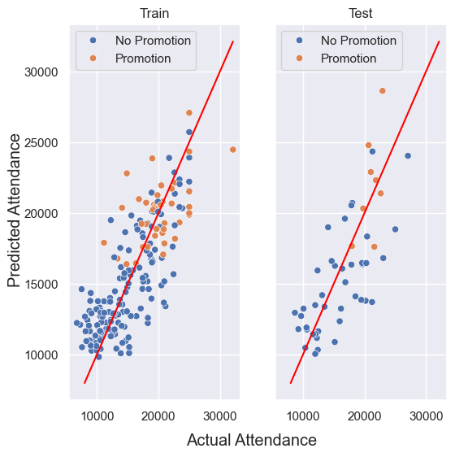

```python
#Creating a dataframe to plot
train_predictions = pd.DataFrame(ATT_split.predict(W_train), columns = ['Predicted'])
train = Z_train
train = train.reset_index()
train = train.drop('index', axis = 1)
train = pd.merge(train,train_predictions, left_index=True, right_index=True)
train_promo = W_train.drop(W_train.columns[[0,5,6,7,8,9,10,11,12,13,14,15,16,17,18,19,20,21,22,23,24,25,26,27,28,29,30,31,32,33,34,35,36,37,38,39,40,41,42,43,44,45,46,47]], axis = 1)
train_promo = train_promo.reset_index()
conditions = [(train_promo['Promotion: Apparel'] == True), (train_promo['Promotion: Bobblehead'] == True),
              (train_promo['Promotion: Kids'] == True), (train_promo['Promotion: Misc'] == True)]
values = ['Promotion', 'Promotion','Promotion','Promotion']
train_promo['Promotion'] = np.select(conditions, values, default='No Promotion')
train_promo = train_promo.drop(train_promo.columns[[0,1,2,3,4]], axis = 1)
train = pd.merge(train,train_promo, left_index=True, right_index=True)

test_predictions = pd.DataFrame(ATT_split.predict(W_test), columns = ['Predicted'])
test = Z_test
test = test.reset_index()
test = test.drop('index', axis = 1)
test = pd.merge(test,test_predictions, left_index=True, right_index=True)
test_promo = W_test.drop(W_test.columns[[0,5,6,7,8,9,10,11,12,13,14,15,16,17,18,19,20,21,22,23,24,25,26,27,28,29,30,31,32,33,34,35,36,37,38,39,40,41,42,43,44,45,46,47]], axis = 1)
test_promo = test_promo.reset_index()
conditions = [(test_promo['Promotion: Apparel'] == True), (test_promo['Promotion: Bobblehead'] == True),
              (test_promo['Promotion: Kids'] == True), (test_promo['Promotion: Misc'] == True)]
values = ['Promotion', 'Promotion','Promotion','Promotion']
test_promo['Promotion'] = np.select(conditions, values, default='No Promotion')
test_promo = test_promo.drop(test_promo.columns[[0,1,2,3,4]], axis = 1)
test = pd.merge(test,test_promo, left_index=True, right_index=True)

#Creating the scatterplots for actual attendance vs predicted
fig, axes = plt.subplots(1, 2, sharex=True, sharey=True, figsize=(6,6))
fig.supxlabel('Actual Attendance')
fig.supylabel('Predicted Attendance',x = 0)

sns.scatterplot(x = train['Attendance'], y = train['Predicted'], hue = train['Promotion'], ax = axes[0])

x = np.linspace(8000, max(attendance_merged['Attendance']), 100)
y = x
sns.lineplot(x = x, y = x, color='red', ax = axes[0])
axes[0].set_xlabel("")
axes[0].set_ylabel("")

# Customizing the plot
sns.scatterplot(x = test['Attendance'], y = test['Predicted'], hue = test['Promotion'], ax = axes[1])

sns.lineplot(x = x, y = x, color='red', ax = axes[1])
axes[1].set_xlabel("")
axes[1].set_ylabel("")

axes[0].set_title('Train')
axes[1].set_title('Test')

plt.show()
```

## References

Miller, Thomas W. 2025. Sports Analytics and Data Science: Winning the Game with Methods and Models. 1st ed. FT Press.

“2022 Tampa Bay Rays Schedule.” n.d. Baseball Reference.

> https://www.baseball-reference.com/teams/TBR/2022-schedule-scores.shtml.

“2023 Tampa Bay Rays Schedule.” n.d. Baseball Reference.

> https://www.baseball-reference.com/teams/TBR/2023-schedule-scores.shtml.

“2024 Major League Baseball Attendance & Team Age.” n.d. Baseball Reference.

> https://www.baseball-reference.com/leagues/majors/2024-misc.shtml.

“2024 Tampa Bay Rays Schedule.” n.d. Baseball Reference.

> https://www.baseball-reference.com/teams/TBR/2024-schedule-scores.shtml.

Russell, Daniel. 2023. “Rays Announce $10 Tickets, Promotional Schedule.” DRaysBay, February 7, 2023.

> https://www.draysbay.com/2023/2/7/23589971/rays-announce-10-tickets-promotional-schedule.

Russell, Daniel. 2024. “Rays Announce 2024 Promotional Schedule, Two Additions to Hall of Fame.” DRaysBay, February 14, 2024.

> https://www.draysbay.com/2024/2/14/24073195/rays-announce-2024-promotional-schedule-two-additions-to-hall-of-fame.

Trujillo, Dan. 2022. “Rays announce ticket info, promotional schedule for 2022 season.” ABC Action News Tampa Bay (WFTS), January 31, 2022.

> https://www.abcactionnews.com/sports/baseball/rays/rays-announce-ticket-info-promotional-schedule-for-2022-season.

“Tampa Bay Rays on the Forbes MLB Team Valuations List.” 2025. Forbes. March 2025.

> https://www.forbes.com/teams/tampa-bay-rays/.